# Data Collection Assignment 3

2025-09-24

## Downloading data

I first use the load_variable() command to search the code list. I select two variables for analysis: Chinese, which is the total number of Chinese excluding Taiwanese, and Gross_rent, which is the median gross rent. All data are at the county level. Then, I use get_acs() to retrieve the data and keep the estimate and margin of error in a wide-format data frame.

```r
vars <- load_variables(2023, "acs5", cache = TRUE) # Check variable list

state_abbr <- "TX"
geo_level  <- "county"   # options: state, county, tract, block group
my_vars    <- c(chinese = "B02015_002", gross_rent = "B25064_001")
year_acs   <- 2023
survey     <- "acs5"

# Use the get_acs function to download the data
acs <- get_acs(
    geography = geo_level,
    variables = my_vars,
    state = state_abbr,
    # county = "Hansford",  (Switch to county results)
    year = year_acs,
    survey = survey,
    geometry = TRUE
)

# Convert table from long to wide for ggplot2
acs_wide <- acs |>
    tidyr::pivot_wider(
        id_cols = c(GEOID, NAME, geometry),
        names_from = variable,
        values_from = c(estimate, moe)
    )
```

## Plot 1

The results show that Chinese populations are mainly concentrated in the metropolitan areas of Texas, including Houston, Austin, San Antonio, and Dallas–Fort Worth. Among all Texan cities, Houston has the highest number of Chinese residents.

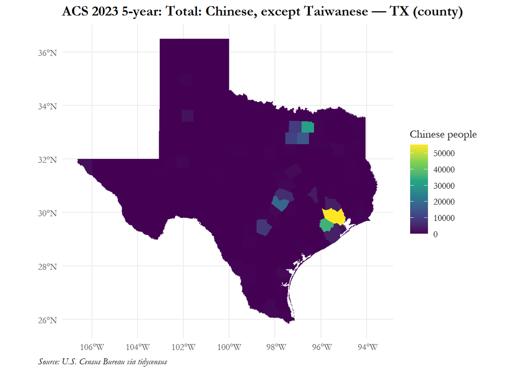

```r
ggplot(acs_wide) +
    geom_sf(aes(fill = estimate_chinese), color = NA) +
    scale_fill_viridis_c(name = "Chinese people") +
    labs(title = paste0("ACS ", year_acs, " 5-year: Total: Chinese, except Taiwanese — ", state_abbr, " (", geo_level, ")"),
         caption = "Source: U.S. Census Bureau via tidycensus") +
    theme(plot.title = element_text(hjust = 0, size = 14, face = "bold"),
          plot.caption = element_text(hjust = 0, face = "italic"),
          plot.caption.position = "plot", # Relative to plot
    )
```

## Plot 2

The second plot shows the median gross rent. As expected, the metropolitan counties have the highest rents. The heatmap also indicates that the eastern Texas counties generally have higher rents than the less populous western counties.

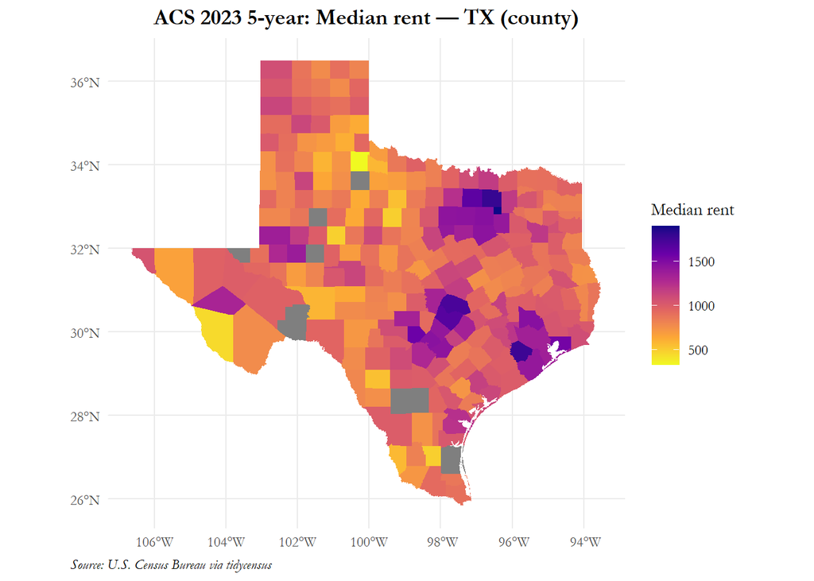

```r
ggplot(acs_wide) +
    geom_sf(aes(fill = estimate_gross_rent), color = NA) +
    scale_fill_viridis_c(name = "Median rent", direction = -1, option = "plasma") +
    labs(title = paste0("ACS ", year_acs, " 5-year: Median rent — ", state_abbr, " (", geo_level, ")"),
         caption = "Source: U.S. Census Bureau via tidycensus") +
    theme(plot.title = element_text(hjust = 0.5, size = 14, face = "bold"),
          plot.caption = element_text(hjust = 0, face = "italic"),
          plot.caption.position = "plot", # Relative to plot
  )
```

## Table

The counties with the highest gross rents are the suburbs of the major Texan cities, including Rockwall and Collin near Dallas, Fort Bend near Houston, and Williamson near Austin.

The counties with the lowest gross rents are the sparsely populated counties in West Texas.

```
## # A tibble: 10 x 3
##    NAME                     estimate_gross_rent moe_gross_rent
##    <chr>                                  <dbl>          <dbl>
##  1 Rockwall County, Texas                  1899            108
##  2 Collin County, Texas                    1792             16
##  3 Fort Bend County, Texas                 1770             33
##  4 Williamson County, Texas                1720             23
##  5 Travis County, Texas                    1669             12
##  6 Denton County, Texas                    1642             21
##  7 Kendall County, Texas                   1576             97
##  8 Chambers County, Texas                  1548            163
##  9 Montgomery County, Texas                1471             24
## 10 Dallas County, Texas                    1469              8
```

```
## # A tibble: 10 x 3
##    NAME                       estimate_gross_rent moe_gross_rent
##    <chr>                                    <dbl>          <dbl>
##  1 Cottle County, Texas                       323            154
##  2 Presidio County, Texas                     445             51
##  3 Mitchell County, Texas                     481            295
##  4 Shackelford County, Texas                  485            296
##  5 Brooks County, Texas                       487            171
##  6 Zavala County, Texas                       544            176
##  7 Throckmorton County, Texas                 548            405
##  8 Zapata County, Texas                       569             23
##  9 Foard County, Texas                        577             14
## 10 Crockett County, Texas                     585            154
```